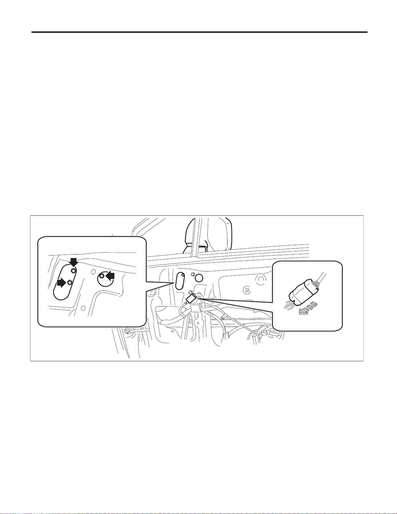

GW-26

Outer Mirror Assembly

GLASS/WINDOWS/MIRRORS

8. Outer Mirror Assembly

A: REMOVAL

Refer to “DISASSEMBLY” for removal procedures of scalp cap and mirror face. <Ref. to GW-27, DISAS-

SEMBLY, Outer Mirror Assembly.>

1) Disconnect the ground cable from battery and wait for at least 60 seconds before starting work. <Ref. to

NT-5, BATTERY, NOTE, Note.>

NOTE:

For models other than STI model, disconnect the ground terminal from battery sensor.

2) Remove the trim panel - front door. <Ref. to EI-56, FRONT DOOR, REMOVAL, Door Trim.>

3) Turn over the sealing cover - front door.

CAUTION:

• Carefully remove the butyl tape. Excessive force will easily break the sealing cover - front door.

• If the sealing cover - front door gets broken, replace it with a new part.

• Be careful not to allow the butyl tape to contact any trims and seats because the butyl tape, which

has a strong adhesive force, is difficult to remove once it adhered.

(1) Remove the connector clip that is installed on the panel assembly - front door, and disconnect the

connector.

(2) Carefully remove and turn over the sealing cover - front door within the area where the operation can

be performed.

4) Remove the bolts to remove outer mirror assembly.

B: INSTALLATION

CAUTION:

Be careful not to catch the harness in between the parts.

1) Install the outer mirror assembly.

Tightening torque:

7.5 N·m (0.8 kgf-m, 5.5 ft-lb)

2) Install the sealing cover - front door.

3) Install the trim panel - front door.

4) Connect the battery ground terminal. <Ref. to NT-5, BATTERY, NOTE, Note.>

NOTE:

For models other than STI model, connect the ground terminal to battery sensor.

GW-01364

15WRX_STI_US_EN.book 26 ページ ２０１５年２月１３日 金曜日 午前１１時２０分

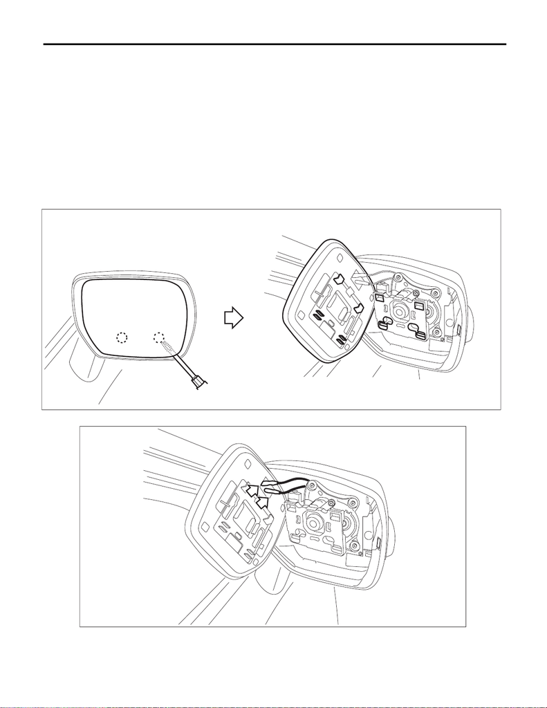

GW-27

Outer Mirror Assembly

GLASS/WINDOWS/MIRRORS

C: DISASSEMBLY

CAUTION:

• When removing the mirror - repair, be careful not to damage the back surface of mirror - repair with

a flat tip screwdriver.

• When installing the mirror - repair, insert the connector and clip securely.

1) Operate the remote control mirror switch to face the mirror - repair upward.

2) Disconnect the ground cable from battery and wait for at least 60 seconds before starting work. <Ref. to

NT-5, BATTERY, NOTE, Note.>

NOTE:

For models other than STI model, disconnect the ground terminal from battery sensor.

3) Remove the mirror - repair.

(1) Using a flat tip screwdriver or similar tool, release the engagement shown in the figure, and slide the

mirror - repair downward to remove.

(2) Disconnect the mirror heater connector. (Model with mirror heater)

GW-01385

GW-01031

15WRX_STI_US_EN.book 27 ページ ２０１５年２月１３日 金曜日 午前１１時２０分

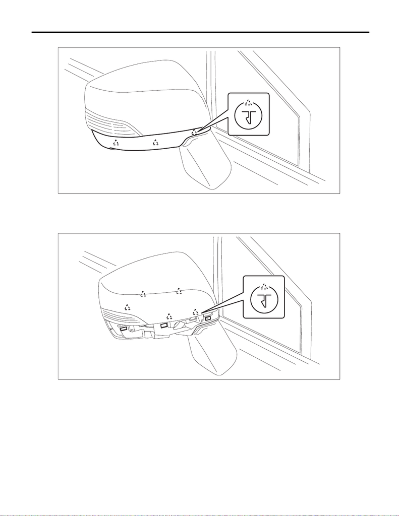

GW-28

Outer Mirror Assembly

GLASS/WINDOWS/MIRRORS

4) Release the claws, and then remove the cover - cap outer mirror lower.

5) Release the claws, and then remove the cover - cap outer mirror.

CAUTION:

Be careful not to apply excessive force when removing the cover - cap outer mirror, as the lower

hooks may become damaged.

GW-01032

GW-01396

15WRX_STI_US_EN.book 28 ページ ２０１５年２月１３日 金曜日 午前１１時２０分

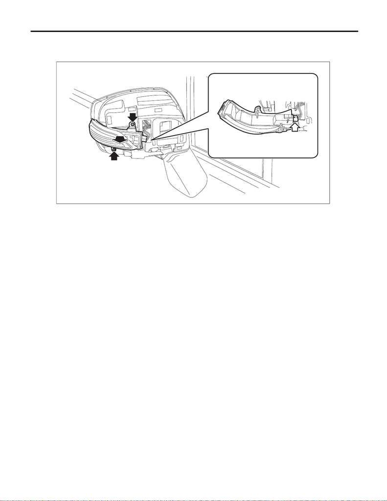

GW-29

Outer Mirror Assembly

GLASS/WINDOWS/MIRRORS

6) Remove the light assembly - side turn mirror. (Model with side turn signal light)

(1) Remove the screws and pull out the light assembly - side turn mirror to the front of the vehicle.

(2) Disconnect the connector and remove the light assembly - side turn mirror.

D: ASSEMBLY

CAUTION:

Be careful not to catch the harness in between the parts.

1) Install the light assembly - side turn mirror.

2) Install the cover - cap outer mirror.

3) Install the cover - cap outer mirror lower.

4) Check that all the claws are securely engaged.

LI-01214

15WRX_STI_US_EN.book 29 ページ ２０１５年２月１３日 金曜日 午前１１時２０分

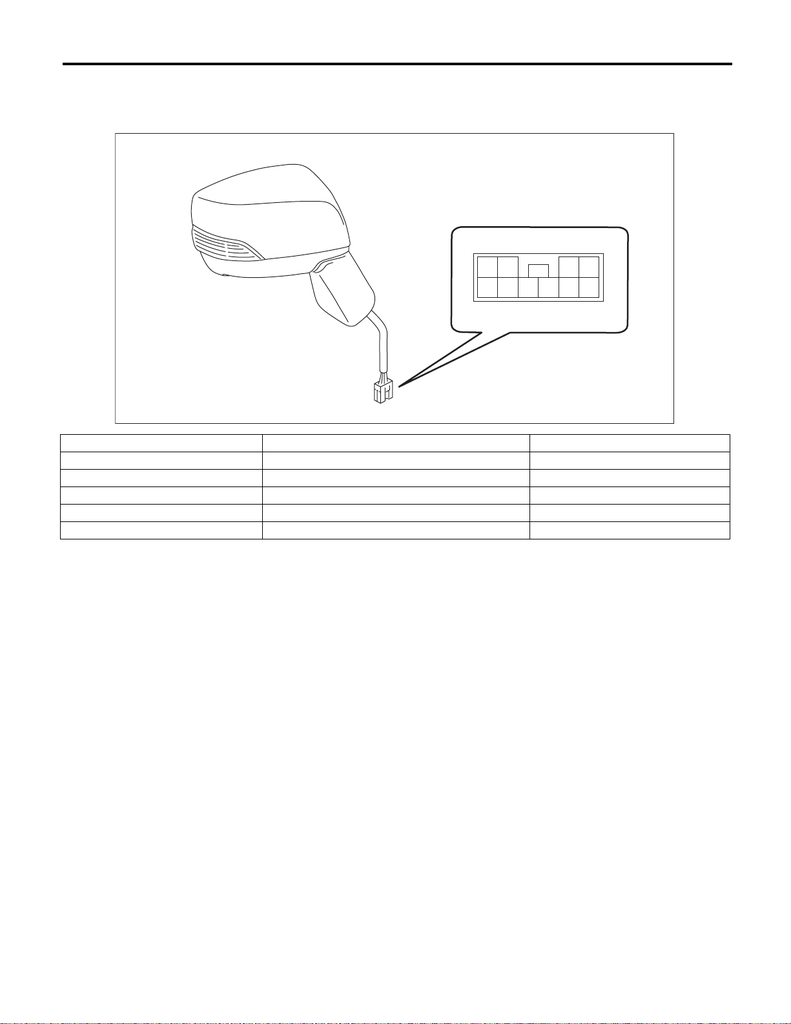

GW-30

Outer Mirror Assembly

GLASS/WINDOWS/MIRRORS

E: INSPECTION

1) Disconnect the outer mirror connector.

2) Apply battery voltage between the outer mirror connector terminals and check the mirror operation.

3) If it does not operate normally, replace the outer mirror assembly.

Terminal No. Inspection conditions Switch position

— — OFF

3 (+) — 8(–) Apply battery voltage between terminals. UP

8 (+) — 3(–) Apply battery voltage between terminals. DOWN

7 (+) — 3(–) Apply battery voltage between terminals. LEFT

3 (+) — 7(–) Apply battery voltage between terminals. RIGHT

GW-01037

432

109587

6

1

15WRX_STI_US_EN.book 30 ページ ２０１５年２月１３日 金曜日 午前１１時２０分